# ml-assignment

Eterna2

Sunday, May 24, 2015

## Summary

We were able to achieve a 0.25% out-of-bag estimate of the error rate. And successfully predicted all 20 test samples provided.

## Environment Setup

```r
# ensure the results are repeatable
set.seed(2)
# load the library
library(caret)
```

```r
library(ggplot2)
```

## Data Preparation

The training set is loaded and examined (Appendix A).

```r
# load training data
training <- read.csv("pml-training.csv")
training$classe <- as.factor(training$classe)
```

The training set is subset to remove features that are not very useful - those that are too sparse or are sub-features (e.g. kurtosis, skewness, min, max, average, stdev, var, etc) or not likely to be relevant for the class prediction (e.g. user name, timestamp, window, etc).

```r
# keep only relevant features
training.sub <- subset(training,select=c(
  classe,
  roll_belt,
  pitch_belt,
  yaw_belt,
  total_accel_belt,
  gyros_belt_x,
  gyros_belt_y,
  gyros_belt_z,
  accel_belt_x,
  accel_belt_y,
  accel_belt_z,
  magnet_belt_x,
  magnet_belt_y,
  magnet_belt_z,
  roll_arm,
  pitch_arm,
  yaw_arm,
  total_accel_arm,
  gyros_arm_x,
  gyros_arm_y,
  gyros_arm_z,
  accel_arm_x,
  accel_arm_y,
  accel_arm_z,
  magnet_arm_x,
  magnet_arm_y,
  magnet_arm_z,
  roll_dumbbell,
  pitch_dumbbell,
  yaw_dumbbell,
  total_accel_dumbbell,
  gyros_dumbbell_x,
  gyros_dumbbell_y,
  gyros_dumbbell_z,
  accel_dumbbell_x,
  accel_dumbbell_y,
  accel_dumbbell_z,
  magnet_dumbbell_x,
  magnet_dumbbell_y,
  magnet_dumbbell_z,
  roll_forearm,
  pitch_forearm,
  yaw_forearm,
  total_accel_forearm,
  gyros_forearm_x,
  gyros_forearm_y,
  gyros_forearm_z,
  accel_forearm_x,
  accel_forearm_y,
  accel_forearm_z,
  magnet_forearm_x,
  magnet_forearm_y,
  magnet_forearm_z
))
```

Next, we check for predictors with near zero variances. This is to prevent undue influences from such predictors during cross-validation and/or bootstrapping. Everything looks fine.

```r
# check for zero variances
nearZeroVar(training.sub[,-1], saveMetrics= TRUE)
```

```
##                      freqRatio percentUnique zeroVar   nzv
## roll_belt             1.101904     6.7781062   FALSE FALSE
## pitch_belt            1.036082     9.3772296   FALSE FALSE
## yaw_belt              1.058480     9.9734991   FALSE FALSE
## total_accel_belt      1.063160     0.1477933   FALSE FALSE
## gyros_belt_x          1.058651     0.7134849   FALSE FALSE
## gyros_belt_y          1.144000     0.3516461   FALSE FALSE
## gyros_belt_z          1.066214     0.8612782   FALSE FALSE
## accel_belt_x          1.055412     0.8357966   FALSE FALSE
## accel_belt_y          1.113725     0.7287738   FALSE FALSE
## accel_belt_z          1.078767     1.5237998   FALSE FALSE
## magnet_belt_x         1.090141     1.6664968   FALSE FALSE
## magnet_belt_y         1.099688     1.5187035   FALSE FALSE
## magnet_belt_z         1.006369     2.3290184   FALSE FALSE
## roll_arm             52.338462    13.5256345   FALSE FALSE
## pitch_arm            87.256410    15.7323412   FALSE FALSE
## yaw_arm              33.029126    14.6570176   FALSE FALSE
## total_accel_arm       1.024526     0.3363572   FALSE FALSE
## gyros_arm_x           1.015504     3.2769341   FALSE FALSE
## gyros_arm_y           1.454369     1.9162165   FALSE FALSE
## gyros_arm_z           1.110687     1.2638875   FALSE FALSE
## accel_arm_x           1.017341     3.9598410   FALSE FALSE
## accel_arm_y           1.140187     2.7367241   FALSE FALSE
## accel_arm_z           1.128000     4.0362858   FALSE FALSE
## magnet_arm_x          1.000000     6.8239731   FALSE FALSE
## magnet_arm_y          1.056818     4.4439914   FALSE FALSE
## magnet_arm_z          1.036364     6.4468454   FALSE FALSE
## roll_dumbbell         1.022388    84.2065029   FALSE FALSE
## pitch_dumbbell        2.277372    81.7449801   FALSE FALSE
## yaw_dumbbell          1.132231    83.4828254   FALSE FALSE
## total_accel_dumbbell  1.072634     0.2191418   FALSE FALSE
## gyros_dumbbell_x      1.003268     1.2282132   FALSE FALSE
## gyros_dumbbell_y      1.264957     1.4167771   FALSE FALSE
## gyros_dumbbell_z      1.060100     1.0498420   FALSE FALSE
## accel_dumbbell_x      1.018018     2.1659362   FALSE FALSE
## accel_dumbbell_y      1.053061     2.3748853   FALSE FALSE
## accel_dumbbell_z      1.133333     2.0894914   FALSE FALSE
## magnet_dumbbell_x     1.098266     5.7486495   FALSE FALSE
## magnet_dumbbell_y     1.197740     4.3012945   FALSE FALSE
## magnet_dumbbell_z     1.020833     3.4451126   FALSE FALSE
## roll_forearm         11.589286    11.0895933   FALSE FALSE
## pitch_forearm        65.983051    14.8557741   FALSE FALSE
## yaw_forearm          15.322835    10.1467740   FALSE FALSE
## total_accel_forearm   1.128928     0.3567424   FALSE FALSE
## gyros_forearm_x       1.059273     1.5187035   FALSE FALSE
## gyros_forearm_y       1.036554     3.7763735   FALSE FALSE
## gyros_forearm_z       1.122917     1.5645704   FALSE FALSE
## accel_forearm_x       1.126437     4.0464784   FALSE FALSE
## accel_forearm_y       1.059406     5.1116094   FALSE FALSE
## accel_forearm_z       1.006250     2.9558659   FALSE FALSE
## magnet_forearm_x      1.012346     7.7667924   FALSE FALSE
## magnet_forearm_y      1.246914     9.5403119   FALSE FALSE
## magnet_forearm_z      1.000000     8.5771073   FALSE FALSE
```

```r
# calculate correlation matrix
correlationMatrix = cor(training.sub[,-1])
# find attributes that are highly corrected
highlyCorrelated = findCorrelation(correlationMatrix, cutoff=0.75)
# filter away highly correlated predictors
training.sub2 = cbind(classe=training.sub[,1],(training.sub[,-1])[,-highlyCorrelated])
# print highly correlated attributes
print(colnames(training.sub[,-1])[highlyCorrelated])
```

```
##  [1] "accel_belt_z"      "roll_belt"         "accel_belt_y"
##  [4] "accel_arm_y"       "total_accel_belt"  "accel_dumbbell_z"
##  [7] "accel_belt_x"      "pitch_belt"        "magnet_dumbbell_x"
## [10] "accel_dumbbell_y"  "magnet_dumbbell_y" "accel_arm_x"
## [13] "accel_dumbbell_x"  "accel_arm_z"       "magnet_arm_y"
## [16] "magnet_belt_y"     "accel_forearm_y"   "gyros_arm_y"
## [19] "gyros_forearm_z"   "gyros_dumbbell_x"
```

As the number of features are still significant, we employed a recursive feature selection algorithm using random forest.

```r
# define the control using a random forest selection function
control <- rfeControl(functions=rfFuncs, method="cv", number=10)
# run the RFE algorithm
results <- rfe(training.sub[,-1], training.sub[,1], rfeControl=control)
```

As shown in the results below, we can achieve an accuracy of 98.8% just by using 8 features.

```r
# summarize the results
print(results)
```

```
##
## Recursive feature selection
##
## Outer resampling method: Cross-Validated (10 fold)
##
## Resampling performance over subset size:
##
##  Variables Accuracy  Kappa AccuracySD  KappaSD Selected
##          4   0.9510 0.9380   0.003453 0.004367
##          8   0.9887 0.9857   0.005920 0.007485
##         16   0.9945 0.9930   0.001696 0.002145
##         52   0.9972 0.9965   0.001425 0.001803        *
##
## The top 5 variables (out of 52):
##    roll_belt, yaw_belt, magnet_dumbbell_z, pitch_belt, magnet_dumbbell_y
```

```r
# list the chosen features
predictors(results)
```

```
##  [1] "roll_belt"            "yaw_belt"             "magnet_dumbbell_z"
##  [4] "pitch_belt"           "magnet_dumbbell_y"    "pitch_forearm"
##  [7] "accel_dumbbell_y"     "magnet_forearm_z"     "roll_forearm"
## [10] "roll_dumbbell"        "roll_arm"             "magnet_dumbbell_x"
## [13] "accel_dumbbell_z"     "gyros_arm_y"          "magnet_belt_z"
## [16] "gyros_belt_z"         "magnet_belt_y"        "yaw_arm"
## [19] "magnet_belt_x"        "gyros_forearm_y"      "accel_forearm_x"
## [22] "accel_belt_z"         "yaw_dumbbell"         "accel_forearm_z"
## [25] "gyros_arm_x"          "magnet_arm_z"         "magnet_forearm_y"
## [28] "total_accel_dumbbell" "gyros_dumbbell_y"     "yaw_forearm"
## [31] "gyros_dumbbell_x"     "accel_forearm_y"      "gyros_forearm_z"
## [34] "pitch_arm"            "gyros_dumbbell_z"     "accel_dumbbell_x"
## [37] "accel_arm_y"          "magnet_forearm_x"     "accel_arm_z"
## [40] "total_accel_forearm"  "total_accel_arm"      "accel_arm_x"
## [43] "gyros_belt_x"         "magnet_arm_x"         "magnet_arm_y"
## [46] "gyros_forearm_x"      "accel_belt_x"         "gyros_belt_y"
## [49] "pitch_dumbbell"       "total_accel_belt"     "gyros_arm_z"
## [52] "accel_belt_y"
```

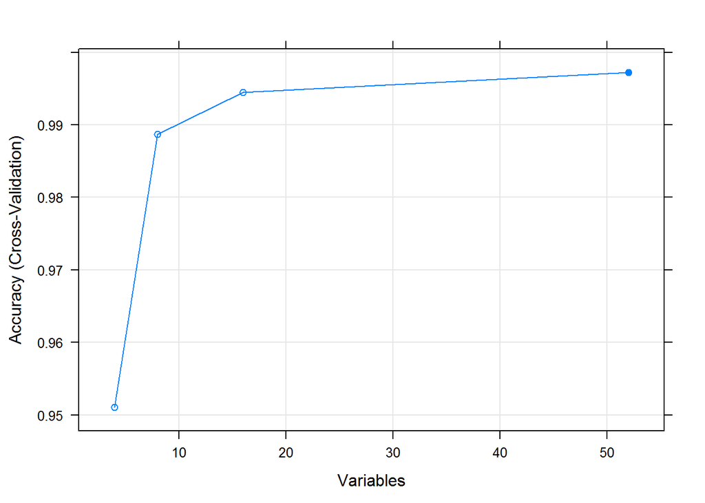

```r
# plot the results
plot(results, type=c("g", "o"))
```

This is the resultant model we gotten with the corresponding confusion matrix. The out-of-bag estimate of error rate is 0.25% which is a good estimate of the out of sample error rate.

```r
print(results$fit)
```

```
##
## Call:
##  randomForest(x = x, y = y, importance = first)
##                Type of random forest: classification
##                      Number of trees: 500
## No. of variables tried at each split: 7
##
##         OOB estimate of  error rate: 0.25%
## Confusion matrix:
##      A    B    C    D    E  class.error
## A 5578    1    0    0    1 0.0003584229
## B   10 3784    3    0    0 0.0034237556
## C    0    8 3414    0    0 0.0023378141
## D    0    0   20 3194    2 0.0068407960
## E    0    0    0    5 3602 0.0013861935
```

Applying the model on the test set, we get the following predictions.

```r
# load test set
testing <- read.csv("pml-testing.csv")
# predict the response for the test set
answer <- predict(results, testing)
# print prediction
print(answer)
```

```
##    pred     A     B     C     D     E
## 1     B 0.052 0.820 0.114 0.002 0.012
## 2     A 0.956 0.020 0.022 0.000 0.002
## 3     B 0.114 0.722 0.098 0.012 0.054
## 4     A 0.938 0.002 0.038 0.020 0.002
## 5     A 0.960 0.012 0.022 0.006 0.000
## 6     E 0.008 0.058 0.084 0.024 0.826
## 7     D 0.010 0.008 0.054 0.916 0.012
## 8     B 0.054 0.762 0.062 0.092 0.030
## 9     A 0.998 0.000 0.000 0.000 0.002
## 10    A 0.992 0.006 0.002 0.000 0.000
## 11    B 0.032 0.840 0.068 0.030 0.030
## 12    C 0.018 0.040 0.878 0.014 0.050
## 13    B 0.006 0.978 0.002 0.006 0.008
## 14    A 1.000 0.000 0.000 0.000 0.000
## 15    E 0.006 0.018 0.018 0.014 0.944
## 16    E 0.008 0.036 0.000 0.006 0.950
## 17    A 0.986 0.000 0.000 0.000 0.014
## 18    B 0.044 0.894 0.008 0.044 0.010
## 19    B 0.090 0.886 0.012 0.010 0.002
## 20    B 0.000 0.998 0.002 0.000 0.000
```

## Appendix A - Summary of training data

```r
# examine data
summary(training)
```

```
##        X            user_name    raw_timestamp_part_1 raw_timestamp_part_2
##  Min.   :    1   adelmo  :3892   Min.   :1.322e+09    Min.   :   294
##  1st Qu.: 4906   carlitos:3112   1st Qu.:1.323e+09    1st Qu.:252912
##  Median : 9812   charles :3536   Median :1.323e+09    Median :496380
##  Mean   : 9812   eurico  :3070   Mean   :1.323e+09    Mean   :500656
##  3rd Qu.:14717   jeremy  :3402   3rd Qu.:1.323e+09    3rd Qu.:751891
##  Max.   :19622   pedro   :2610   Max.   :1.323e+09    Max.   :998801
##
##           cvtd_timestamp  new_window    num_window      roll_belt
##  28/11/2011 14:14: 1498   no :19216   Min.   :  1.0   Min.   :-28.90
##  05/12/2011 11:24: 1497   yes:  406   1st Qu.:222.0   1st Qu.:  1.10
##  30/11/2011 17:11: 1440               Median :424.0   Median :113.00
##  05/12/2011 11:25: 1425               Mean   :430.6   Mean   : 64.41
##  02/12/2011 14:57: 1380               3rd Qu.:644.0   3rd Qu.:123.00
##  02/12/2011 13:34: 1375               Max.   :864.0   Max.   :162.00
##  (Other)         :11007
##    pitch_belt          yaw_belt       total_accel_belt kurtosis_roll_belt
##  Min.   :-55.8000   Min.   :-180.00   Min.   : 0.00             :19216
##  1st Qu.:  1.7600   1st Qu.: -88.30   1st Qu.: 3.00    #DIV/0!  :   10
##  Median :  5.2800   Median : -13.00   Median :17.00    -1.908453:    2
##  Mean   :  0.3053   Mean   : -11.21   Mean   :11.31    -0.016850:    1
##  3rd Qu.: 14.9000   3rd Qu.:  12.90   3rd Qu.:18.00    -0.021024:    1
##  Max.   : 60.3000   Max.   : 179.00   Max.   :29.00    -0.025513:    1
##                                                        (Other)  :  391
##  kurtosis_picth_belt kurtosis_yaw_belt skewness_roll_belt
##           :19216            :19216              :19216
##  #DIV/0!  :   32     #DIV/0!:  406     #DIV/0!  :    9
##  47.000000:    4                       0.000000 :    4
##  -0.150950:    3                       0.422463 :    2
##  -0.684748:    3                       -0.003095:    1
##  -1.750749:    3                       -0.010002:    1
##  (Other)  :  361                       (Other)  :  389
##  skewness_roll_belt.1 skewness_yaw_belt max_roll_belt     max_picth_belt
##           :19216             :19216     Min.   :-94.300   Min.   : 3.00
##  #DIV/0!  :   32      #DIV/0!:  406     1st Qu.:-88.000   1st Qu.: 5.00
##  0.000000 :    4                        Median : -5.100   Median :18.00
##  -2.156553:    3                        Mean   : -6.667   Mean   :12.92
##  -3.072669:    3                        3rd Qu.: 18.500   3rd Qu.:19.00
##  -6.324555:    3                        Max.   :180.000   Max.   :30.00
##  (Other)  :  361                        NA's   :19216     NA's   :19216
```

[output cut: 313 more lines]

```
##  Min.   :-446.00   Min.   :-1280.0   Min.   :-896.0   Min.   :-973.0
##  1st Qu.:-182.00   1st Qu.: -616.0   1st Qu.:   2.0   1st Qu.: 191.0
##  Median : -39.00   Median : -378.0   Median : 591.0   Median : 511.0
##  Mean   : -55.29   Mean   : -312.6   Mean   : 380.1   Mean   : 393.6
##  3rd Qu.:  26.00   3rd Qu.:  -73.0   3rd Qu.: 737.0   3rd Qu.: 653.0
##  Max.   : 291.00   Max.   :  672.0   Max.   :1480.0   Max.   :1090.0
##
##  classe
##  A:5580
##  B:3797
##  C:3422
##  D:3216
##  E:3607
##
##
```

## Appendix B - Correlation matrix

```r
# summarize the correlation matrix
print(correlationMatrix)
```

[output not shown]

[output cut: 846 more lines]

[output not shown]